# COVIID-19 R Example

This R markdown document provides an example of the basic sequence of commands in R to:

- load the needed libraries to perform an analysis
- import data
- reshape and process the data to support an analysis and visualization
- perform an analysis (describe & summarize)
- visualize the data

In this case we will download US COVID-19 infection data for each US county and combine those data with demongraphic data from the US Census Bureau to gain an understanding of per-capita rates of increase in infection relative to some demographic variables of interest.

# Import Libraries

```r
knitr::opts_chunk$set(message = FALSE)
options("scipen"=100, "digits"=4) # tune up when numbers will be displayed in fixed vs. scientific notation
library(tidyverse)    # core meta-package for a bunch of the tidyverse packages
library(readxl)       # read XLS files into a datafram
library(lubridate)    # convenience functions for processing dates
```

```r
library(ggthemes)     # add some great themes to use in our plots
library(RColorBrewer) # add the color brewer color palette
library(knitr)        # combined with kableExtra output tibbles as nicely formatted tables
library(kableExtra)   # combined with kableExtra output tibbles as nicely formatted tables
```

# Import data

To perform our analysis we are going to retrieve and import three datasets:

- US Census Bureau - American Community Survey 5-year (ACS5) population estimates for all US countys from 2018. https://data.census.gov/cedsci/table?q=population%20by%20county&g=0100000US.050000&hidePreview=true&tid=ACSST1Y2018.S0101&vintage=2018
- US Census Bureau - [USA Counties 2011](https://www.census.gov/library/publications/2011/compendia/usa-counties-2011.html) [Land Area Data](https://www2.census.gov/library/publications/2011/compendia/usa-counties/zip/LND.zip) (LAD) and associated [reference data](https://www2.census.gov/library/publications/2011/compendia/usa-counties/zip/Ref.zip). Note that these data are provided as a zipped xls file.
- The current US confirmed COVID-19 infection count by county/territory time series data (C19) from the Johns Hopkins CSSE [Github repository](https://github.com/CSSEGISandData/COVID-19). https://github.com/CSSEGISandData/COVID-19/raw/master/csse_covid_19_data/csse_covid_19_time_series/time_series_covid19_confirmed_US.csv

## ACS5 data import

These data will be imported from a previously downloaded copy of the data from the US Census Bureau web site (referenced above). These data come in the form of a CSV file and an associated CSV file that describes the content of each of the columns in the file. We will use the Tidyverse `read_csv` command to import this file from the local data folder.

```r
# relative path and filename for the csv file to be imported
acs5_filepath <- "data/ACS2018/ACSST5Y2018.S0101_data_with_overlays_2020-04-06T234438.csv"
acs5_raw <- read_csv(acs5_filepath, col_names = TRUE, skip = 1)
```

### Column specifications

```r
glimpse(acs5_raw)
```

```
## Rows: 3,220
## Columns: 458
## $ id                                                                                                             <chr> …
## $ `Geographic Area Name`                                                                                         <chr> …
## $ `Estimate!!Total!!Total population`                                                                            <dbl> …
## $ `Margin of Error!!Total MOE!!Total population`                                                                 <chr> …
## $ `Estimate!!Percent!!Total population`                                                                          <chr> …
## $ `Margin of Error!!Percent MOE!!Total population`                                                               <chr> …
## $ `Estimate!!Male!!Total population`                                                                             <dbl> …
## $ `Margin of Error!!Male MOE!!Total population`                                                                  <chr> …
## $ `Estimate!!Percent Male!!Total population`                                                                     <chr> …
## $ `Margin of Error!!Percent Male MOE!!Total population`                                                          <chr> …
## $ `Estimate!!Female!!Total population`                                                                           <dbl> …
## $ `Margin of Error!!Female MOE!!Total population`                                                                <chr> …
## $ `Estimate!!Percent Female!!Total population`                                                                   <chr> …
```

[output cut: 445 more lines]

### Import problems

```r
problems(acs5_raw)
```

| row | col | expected | actual |
| --- | --- | --- | --- |

## LAD Data Import

These data will be imported from a previously downloaded copy of the data file that was provided by the US Census Bureau as an XLS file. To read this file we have to have previously loaded the `readxl` library into our R session.

```r
# relative path and filename for the xls file to be imported
lad_filepath <- "data/LandArea/LND01.xls"
lad_raw <- read_excel(lad_filepath)
```

### Column specifications

```r
glimpse(lad_raw)
```

```
## Rows: 3,198
## Columns: 34
## $ Areaname    <chr> "UNITED STATES", "ALABAMA", "Autauga, AL", "Baldwin, AL",…
## $ STCOU       <chr> "00000", "01000", "01001", "01003", "01005", "01007", "01…
## $ LND010190F  <dbl> 0, 0, 0, 0, 0, 0, 0, 0, 0, 0, 0, 0, 0, 0, 0, 0, 0, 0, 0, …
## $ LND010190D  <dbl> 3787425.1, 52422.9, 604.5, 2027.1, 904.6, 625.5, 650.6, 6…
## $ LND010190N1 <chr> "0000", "0000", "0000", "0000", "0000", "0000", "0000", "…
## $ LND010190N2 <chr> "0000", "0000", "0000", "0000", "0000", "0000", "0000", "…
## $ LND010200F  <dbl> 0, 0, 0, 0, 0, 0, 0, 0, 0, 0, 0, 0, 0, 0, 0, 0, 0, 0, 0, …
## $ LND010200D  <dbl> 3794083.1, 52419.0, 604.5, 2026.9, 904.5, 626.2, 650.6, 6…
## $ LND010200N1 <chr> "0000", "0000", "0000", "0000", "0000", "0000", "0000", "…
## $ LND010200N2 <chr> "0000", "0000", "0000", "0000", "0000", "0000", "0000", "…
## $ LND110180F  <dbl> 0, 0, 0, 0, 0, 0, 0, 0, 0, 0, 0, 0, 0, 0, 0, 0, 0, 0, 0, …
## $ LND110180D  <dbl> 3539289.2, 50767.2, 597.0, 1589.4, 883.9, 625.0, 643.3, 6…
## $ LND110180N1 <chr> "0000", "0000", "0000", "0000", "0000", "0000", "0000", "…
```

[output cut: 21 more lines]

### Import problems

```r
problems(lad_raw)
```

| row | col | expected | actual |
| --- | --- | --- | --- |

## C19 data import

These data are going to be directly downloaded from the github repository that the Johns Hopkins CSSE updates on a regular basis. By redownloading the current data from the repository our analysis will always reflect the current state of knowledge about infections for each county in the database.

```r
# relative path and filename for the xls file to be imported
c19_filepath <- "https://github.com/CSSEGISandData/COVID-19/raw/master/csse_covid_19_data/csse_covid_19_time_series/time_series_covid19_confirmed_US.csv"
c19_raw <- read_csv(c19_filepath)
```

### Column specifications

```r
glimpse(c19_raw)
```

```
## Rows: 3,253
## Columns: 89
## $ UID            <dbl> 16, 316, 580, 630, 850, 84001001, 84001003, 84001005, …
## $ iso2           <chr> "AS", "GU", "MP", "PR", "VI", "US", "US", "US", "US", …
## $ iso3           <chr> "ASM", "GUM", "MNP", "PRI", "VIR", "USA", "USA", "USA"…
## $ code3          <dbl> 16, 316, 580, 630, 850, 840, 840, 840, 840, 840, 840, …
## $ FIPS           <dbl> 60, 66, 69, 72, 78, 1001, 1003, 1005, 1007, 1009, 1011…
## $ Admin2         <chr> NA, NA, NA, NA, NA, "Autauga", "Baldwin", "Barbour", "…
## $ Province_State <chr> "American Samoa", "Guam", "Northern Mariana Islands", …
## $ Country_Region <chr> "US", "US", "US", "US", "US", "US", "US", "US", "US", …
## $ Lat            <dbl> -14.27, 13.44, 15.10, 18.22, 18.34, 32.54, 30.73, 31.8…
## $ Long_          <dbl> -170.13, 144.79, 145.67, -66.59, -64.90, -86.64, -87.7…
## $ Combined_Key   <chr> "American Samoa, US", "Guam, US", "Northern Mariana Is…
## $ `1/22/20`      <dbl> 0, 0, 0, 0, 0, 0, 0, 0, 0, 0, 0, 0, 0, 0, 0, 0, 0, 0, …
## $ `1/23/20`      <dbl> 0, 0, 0, 0, 0, 0, 0, 0, 0, 0, 0, 0, 0, 0, 0, 0, 0, 0, …
```

[output cut: 76 more lines]

### Import problems

```r
problems(c19_raw)
```

| row | col | expected | actual |
| --- | --- | --- | --- |

# Reshape and process the data to support an analysis and visualization

In this section of the analysis we are going to extract a useful subset of columns from our three datasets and generate derived datasets that can be used for further analysis and visualization. In support of this activity we are going to illustrate the use of several tidyverse dplyr commands:

- `mutate` - generating new columns based on calculated values
- `select` - selecting a subset of columns that should be included in a returned tibble
- `filter` - selecting a subset of rows that meet specified selection criteria

## Extract some key columns from the ACS dataset

The columns that we are interested in for this example are all of the populations for each age category. We are also extracting the full indentifier column (`id`), a subset of the identifier column that represents the combined FIPS code for the state and county (five characters, `st_county`), and a descriptive name of the geography (`area_name`). In the process of extracting the columns the long default names are replaced with more managable ones.

```r
acs5_working <- acs5_raw %>%
  mutate(
    st_county = str_sub(id, -5)
  ) %>%
  select(
    id = id,
    st_county,
    area_name = `Geographic Area Name`,
    pop_total = `Estimate!!Total!!Total population`,
    pop_lt5 =   `Estimate!!Total!!Total population!!AGE!!Under 5 years`,
    pop_5_9 =   `Estimate!!Total!!Total population!!AGE!!5 to 9 years`,
    pop_10_14 = `Estimate!!Total!!Total population!!AGE!!10 to 14 years`,
    pop_15_19 = `Estimate!!Total!!Total population!!AGE!!15 to 19 years`,
    pop_20_24 = `Estimate!!Total!!Total population!!AGE!!20 to 24 years`,
    pop_25_29 = `Estimate!!Total!!Total population!!AGE!!25 to 29 years`,
    pop_30_34 = `Estimate!!Total!!Total population!!AGE!!30 to 34 years`,
    pop_35_39 = `Estimate!!Total!!Total population!!AGE!!35 to 39 years`,
    pop_40_44 = `Estimate!!Total!!Total population!!AGE!!40 to 44 years`,
    pop_45_49 = `Estimate!!Total!!Total population!!AGE!!45 to 49 years`,
    pop_50_54 = `Estimate!!Total!!Total population!!AGE!!50 to 54 years`,
    pop_55_59 = `Estimate!!Total!!Total population!!AGE!!55 to 59 years`,
    pop_60_64 = `Estimate!!Total!!Total population!!AGE!!60 to 64 years`,
    pop_65_69 = `Estimate!!Total!!Total population!!AGE!!65 to 69 years`,
    pop_70_74 = `Estimate!!Total!!Total population!!AGE!!70 to 74 years`,
    pop_75_79 = `Estimate!!Total!!Total population!!AGE!!75 to 79 years`,
    pop_80_84 = `Estimate!!Total!!Total population!!AGE!!80 to 84 years`,
    pop_gt84 =  `Estimate!!Total!!Total population!!AGE!!85 years and over`
  ) %>%
  mutate(
    pop_lt20 = pop_lt5 + pop_5_9 + pop_10_14 + pop_15_19,
    pop_gte65 = pop_65_69 + pop_70_74 + pop_75_79 + pop_80_84 + pop_gt84,
    pct_lt20 = pop_lt20/pop_total,
    pct_gte65 = pop_gte65/pop_total
  )
glimpse(acs5_working)
```

```
## Rows: 3,220
## Columns: 26
## $ id        <chr> "0500000US01001", "0500000US01003", "0500000US01005", "0500…
## $ st_county <chr> "01001", "01003", "01005", "01007", "01009", "01011", "0101…
## $ area_name <chr> "Autauga County, Alabama", "Baldwin County, Alabama", "Barb…
## $ pop_total <dbl> 55200, 208107, 25782, 22527, 57645, 10352, 20025, 115098, 3…
## $ pop_lt5   <dbl> 3263, 11609, 1390, 1275, 3485, 596, 1205, 6562, 1950, 1204,…
## $ pop_5_9   <dbl> 4009, 11689, 1450, 1178, 3632, 634, 1293, 6844, 1728, 1470,…
## $ pop_10_14 <dbl> 3570, 14323, 1677, 1289, 3995, 540, 1274, 7158, 2099, 1520,…
## $ pop_15_19 <dbl> 3855, 12707, 1434, 1514, 3717, 772, 1292, 7773, 1960, 1603,…
## $ pop_20_24 <dbl> 3337, 10790, 1658, 1491, 3189, 706, 1073, 7626, 2525, 1383,…
## $ pop_25_29 <dbl> 3660, 11825, 1863, 1557, 3400, 702, 1238, 8017, 1829, 1437,…
## $ pop_30_34 <dbl> 3404, 11501, 1812, 1518, 3386, 418, 1186, 7000, 1862, 1092,…
## $ pop_35_39 <dbl> 4095, 12428, 1656, 1455, 3040, 862, 1213, 7039, 1861, 1561,…
## $ pop_40_44 <dbl> 3279, 12949, 1448, 1440, 4113, 737, 1188, 6806, 2112, 1356,…
## $ pop_45_49 <dbl> 3874, 13694, 1672, 1813, 3959, 611, 1168, 7148, 2281, 1749,…
## $ pop_50_54 <dbl> 3979, 14636, 1780, 1626, 3988, 711, 1259, 7810, 2367, 1893,…
## $ pop_55_59 <dbl> 4131, 14440, 1657, 1494, 3895, 593, 1460, 7851, 2638, 2047,…
## $ pop_60_64 <dbl> 2694, 14851, 1651, 1216, 3613, 854, 1370, 8078, 2205, 1917,…
## $ pop_65_69 <dbl> 2271, 13141, 1515, 1280, 3330, 575, 1087, 6667, 2089, 1934,…
## $ pop_70_74 <dbl> 2440, 11410, 1305, 842, 2802, 436, 994, 4822, 1686, 1492, 2…
## $ pop_75_79 <dbl> 1498, 7373, 841, 624, 1776, 248, 753, 3524, 1185, 1188, 138…
## $ pop_80_84 <dbl> 1026, 4792, 551, 488, 1459, 182, 415, 2323, 747, 528, 804, …
## $ pop_gt84  <dbl> 815, 3949, 422, 427, 866, 175, 557, 2050, 702, 479, 602, 29…
## $ pop_lt20  <dbl> 14697, 50328, 5951, 5256, 14829, 2542, 5064, 28337, 7737, 5…
## $ pop_gte65 <dbl> 8050, 40665, 4634, 3661, 10233, 1616, 3806, 19386, 6409, 56…
## $ pct_lt20  <dbl> 0.2662, 0.2418, 0.2308, 0.2333, 0.2572, 0.2456, 0.2529, 0.2…
## $ pct_gte65 <dbl> 0.1458, 0.1954, 0.1797, 0.1625, 0.1775, 0.1561, 0.1901, 0.1…
```

## Extract key columns from LAD dataset

The coluns to be extracted from this dataset include the FIPS code for the state and county (`STCOU` in the original dataset, renamed to `st_county`), the descriptive area name (`Areaname` in the original dataset, renamed to `area_name`), and land area in sq. miles from the 2010 census data set (`LND110210D` in the original dataset, renamce to `land_area_sqmi`).

```r
lad_working <- lad_raw %>%
  select(
    st_county = STCOU,
    area_name = Areaname,
    land_area_sqmi = LND110210D
  )
glimpse(lad_working)
```

```
## Rows: 3,198
## Columns: 3
## $ st_county      <chr> "00000", "01000", "01001", "01003", "01005", "01007", …
## $ area_name      <chr> "UNITED STATES", "ALABAMA", "Autauga, AL", "Baldwin, A…
## $ land_area_sqmi <dbl> 3531905.4, 50645.3, 594.4, 1589.8, 884.9, 622.6, 644.8…
```

Build a reference table of state FIPS codes for later use in analysis and visualization

```r
state_fips <- lad_raw %>%
  filter(str_sub(STCOU, -3) == "000") %>%
  mutate(
    st_fips = str_sub(STCOU, 1, 2)
  ) %>%
  select(
    st_fips,
    Areaname
  )
glimpse(state_fips)
```

```
## Rows: 52
## Columns: 2
## $ st_fips  <chr> "00", "01", "02", "04", "05", "06", "08", "09", "10", "11", …
## $ Areaname <chr> "UNITED STATES", "ALABAMA", "ALASKA", "ARIZONA", "ARKANSAS",…
```

## Extract and reshape the C19 dataset

First generate the geography identifier that matches the other datasets from the `UID` field - `st_county`. Then extract the descriptive name for the geography `Combined_Key`, and thre remaining date columns for which there are associated confirmed infection counts.

```r
c19_working_wide <- c19_raw %>%
  mutate(
    st_county = str_sub(UID, -5)
  ) %>%
  select(
    -c(
      iso2,
      iso3,
      code3,
      FIPS,
      Admin2,
      Province_State,
      Country_Region,
      Lat,
      Long_
      ),
    st_county
  )
glimpse(c19_working_wide)
```

```
## Rows: 3,253
## Columns: 81
## $ UID          <dbl> 16, 316, 580, 630, 850, 84001001, 84001003, 84001005, 84…
## $ Combined_Key <chr> "American Samoa, US", "Guam, US", "Northern Mariana Isla…
## $ `1/22/20`    <dbl> 0, 0, 0, 0, 0, 0, 0, 0, 0, 0, 0, 0, 0, 0, 0, 0, 0, 0, 0,…
## $ `1/23/20`    <dbl> 0, 0, 0, 0, 0, 0, 0, 0, 0, 0, 0, 0, 0, 0, 0, 0, 0, 0, 0,…
## $ `1/24/20`    <dbl> 0, 0, 0, 0, 0, 0, 0, 0, 0, 0, 0, 0, 0, 0, 0, 0, 0, 0, 0,…
## $ `1/25/20`    <dbl> 0, 0, 0, 0, 0, 0, 0, 0, 0, 0, 0, 0, 0, 0, 0, 0, 0, 0, 0,…
## $ `1/26/20`    <dbl> 0, 0, 0, 0, 0, 0, 0, 0, 0, 0, 0, 0, 0, 0, 0, 0, 0, 0, 0,…
## $ `1/27/20`    <dbl> 0, 0, 0, 0, 0, 0, 0, 0, 0, 0, 0, 0, 0, 0, 0, 0, 0, 0, 0,…
## $ `1/28/20`    <dbl> 0, 0, 0, 0, 0, 0, 0, 0, 0, 0, 0, 0, 0, 0, 0, 0, 0, 0, 0,…
## $ `1/29/20`    <dbl> 0, 0, 0, 0, 0, 0, 0, 0, 0, 0, 0, 0, 0, 0, 0, 0, 0, 0, 0,…
## $ `1/30/20`    <dbl> 0, 0, 0, 0, 0, 0, 0, 0, 0, 0, 0, 0, 0, 0, 0, 0, 0, 0, 0,…
## $ `1/31/20`    <dbl> 0, 0, 0, 0, 0, 0, 0, 0, 0, 0, 0, 0, 0, 0, 0, 0, 0, 0, 0,…
## $ `2/1/20`     <dbl> 0, 0, 0, 0, 0, 0, 0, 0, 0, 0, 0, 0, 0, 0, 0, 0, 0, 0, 0,…
```

[output cut: 68 more lines]

Reshape the infection data file into a tall format that allows for more efficient generation of time-series analysis of data. We are using the `pivot_longer` function instead of the now depricated `gather` function frequently referenced in the context of reshaping data.

```r
c19_working_tall <- c19_working_wide %>%
  pivot_longer(
    -c(UID, st_county, Combined_Key),
    names_to = "caldate",
    values_to = "count"
  )
glimpse(c19_working_tall)
```

```
## Rows: 253,734
## Columns: 5
## $ UID          <dbl> 16, 16, 16, 16, 16, 16, 16, 16, 16, 16, 16, 16, 16, 16, …
## $ Combined_Key <chr> "American Samoa, US", "American Samoa, US", "American Sa…
## $ st_county    <chr> "16", "16", "16", "16", "16", "16", "16", "16", "16", "1…
## $ caldate      <chr> "1/22/20", "1/23/20", "1/24/20", "1/25/20", "1/26/20", "…
## $ count        <dbl> 0, 0, 0, 0, 0, 0, 0, 0, 0, 0, 0, 0, 0, 0, 0, 0, 0, 0, 0,…
```

## Build a reference table of population density values from a combination of the ACS and LAD data

```r
pop_density <- lad_working %>%
  inner_join(acs5_working, by = "st_county") %>%
  mutate(
    den_total = pop_total/land_area_sqmi,
    den_lt20 = pop_lt20/land_area_sqmi,
    den_gte65 = pop_gte65/land_area_sqmi
  ) %>%
  select(
    -starts_with("pop"),
    -starts_with("pct"),
    -starts_with("area"),
    -id,
    pop_total,
    pop_lt20,
    pop_gte65
  )
glimpse(pop_density)
```

```
## Rows: 3,140
## Columns: 8
## $ st_county      <chr> "01001", "01003", "01005", "01007", "01009", "01011", …
## $ land_area_sqmi <dbl> 594.4, 1589.8, 884.9, 622.6, 644.8, 622.8, 776.8, 605.…
## $ den_total      <dbl> 92.86, 130.90, 29.14, 36.18, 89.40, 16.62, 25.78, 189.…
## $ den_lt20       <dbl> 24.724, 31.657, 6.725, 8.442, 22.999, 4.082, 6.519, 46…
## $ den_gte65      <dbl> 13.542, 25.579, 5.237, 5.880, 15.871, 2.595, 4.899, 31…
## $ pop_total      <dbl> 55200, 208107, 25782, 22527, 57645, 10352, 20025, 1150…
## $ pop_lt20       <dbl> 14697, 50328, 5951, 5256, 14829, 2542, 5064, 28337, 77…
## $ pop_gte65      <dbl> 8050, 40665, 4634, 3661, 10233, 1616, 3806, 19386, 640…
```

# Perform an analysis (describe & summarize) and visualize results

- `group` - aggregate values based on one or more grouping variables
- `summarize` - calculate descriptive statistics for aggregated values
- `ggplot` - flexible plotting package for incrementally building data visualizations

## Aggregate data across all geographies by calendar date

```r
master_ts <- c19_working_tall %>%
  mutate(
    caldate = mdy(caldate),
    day_num = as.numeric(caldate - min(caldate))
  ) %>%
  group_by(caldate, day_num) %>%
  summarize(
    ct = sum(count)
  ) %>%
  mutate(
    ln_ct = log1p(ct)
  ) %>%
  filter(ct > 0)

glimpse(master_ts)
```

```
## Rows: 78
## Columns: 4
## Groups: caldate [78]
## $ caldate <date> 2020-01-22, 2020-01-23, 2020-01-24, 2020-01-25, 2020-01-26, …
## $ day_num <dbl> 0, 1, 2, 3, 4, 5, 6, 7, 8, 9, 10, 11, 12, 13, 14, 15, 16, 17,…
## $ ct      <dbl> 1, 1, 2, 2, 5, 5, 5, 5, 5, 7, 8, 8, 11, 11, 11, 11, 11, 11, 1…
## $ ln_ct   <dbl> 0.6931, 0.6931, 1.0986, 1.0986, 1.7918, 1.7918, 1.7918, 1.791…
```

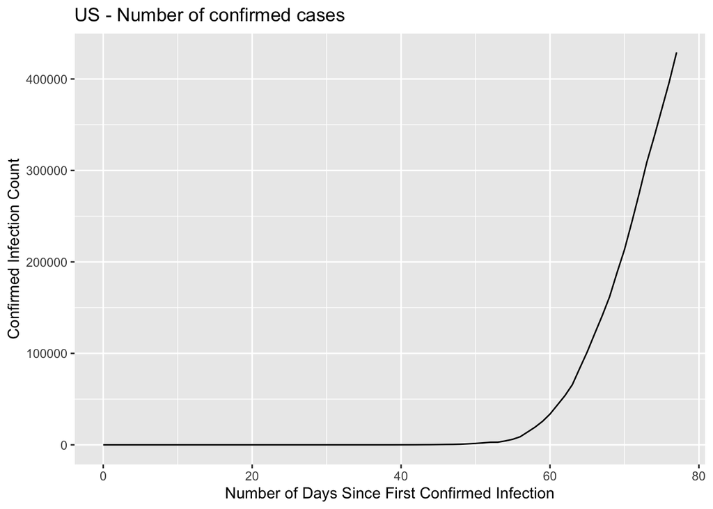

```r
master_plot <- ggplot(master_ts, mapping = aes(x = day_num, y = ct)) +
  geom_line() +
  xlab("Number of Days Since First Confirmed Infection") +
  ylab("Confirmed Infection Count")

master_plot + ggtitle("US - Number of confirmed cases")
```

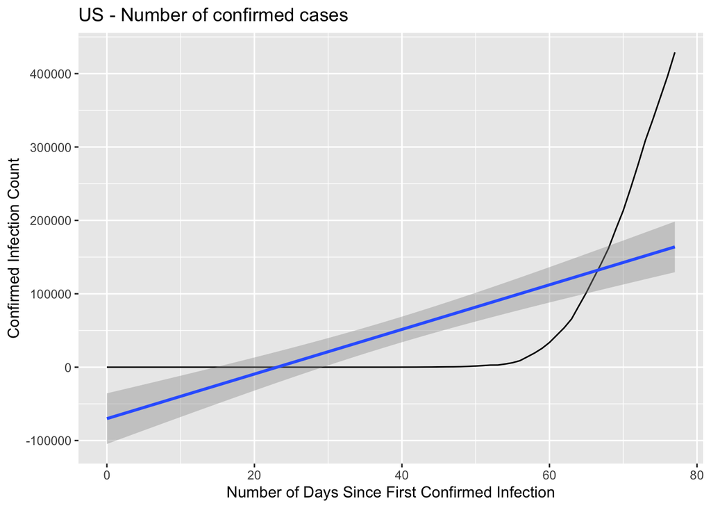

```r
master_plot + ggtitle("US - Number of confirmed cases") + geom_smooth(method="lm")
```

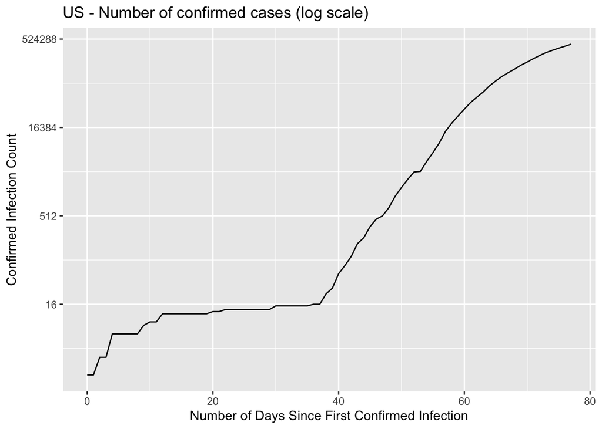

```r
master_plot + ggtitle("US - Number of confirmed cases (log scale)") + scale_y_continuous(trans='log2')
```

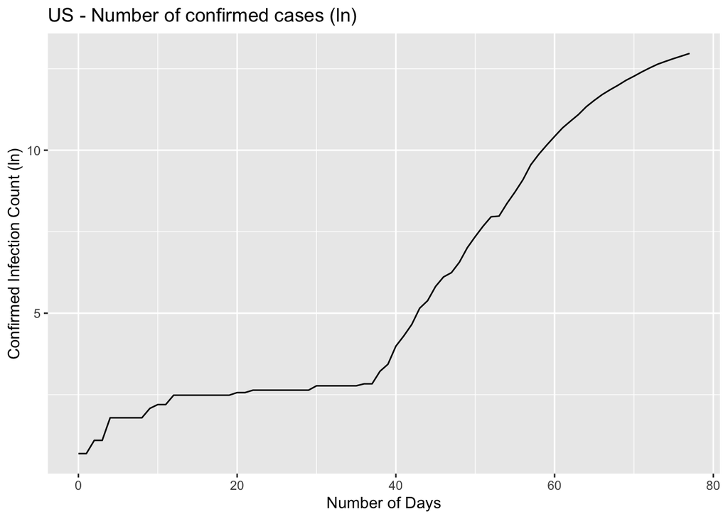

```r
ln_plot <- ggplot(master_ts, mapping = aes(x = day_num, y = ln_ct)) +
  geom_line() +
  xlab("Number of Days") +
  ylab("Confirmed Infection Count (ln)")

ln_plot + ggtitle("US - Number of confirmed cases (ln)")
```

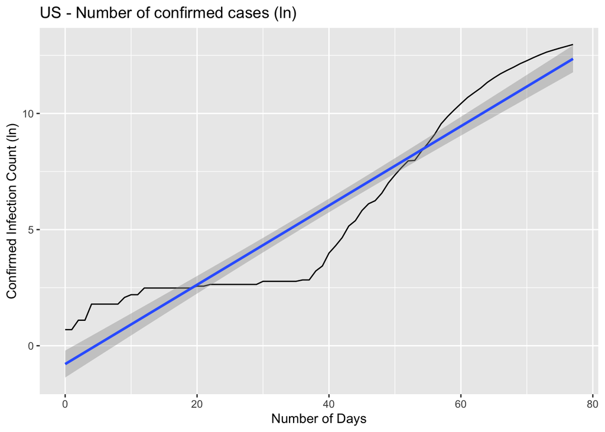

```r
ln_plot + ggtitle("US - Number of confirmed cases (ln)") + geom_smooth(method="lm")
```

## Plot growth by state

```r
# calculate the start date for confirmed infections within the state (based on first confirmed value within a county within the state)
state_start <- c19_working_tall %>%
  filter(str_length(st_county) == 5 & count > 0) %>%
  mutate(
    st_fips = str_sub(st_county, 1, 2),
    caldate = mdy(caldate)
  ) %>%
  inner_join(state_fips) %>%
  group_by(Areaname) %>%
  summarize(
    start_date = min(caldate)
  )
glimpse(state_start)
```

```
## Rows: 51
## Columns: 2
## $ Areaname   <chr> "ALABAMA", "ALASKA", "ARIZONA", "ARKANSAS", "CALIFORNIA", …
## $ start_date <date> 2020-03-13, 2020-03-14, 2020-01-26, 2020-03-14, 2020-01-2…
```

```r
# build the datafram from which plots will be generated
state_ts <- c19_working_tall %>%
  filter(str_length(st_county) == 5 & count > 0) %>%
  mutate(
    st_fips = str_sub(st_county, 1, 2),
    caldate = mdy(caldate)
  ) %>%
  inner_join(state_fips) %>%
  inner_join(pop_density) %>%
  group_by(Areaname, caldate) %>%
  summarize(
    ct = sum(count),
    pop_total = sum(pop_total),
    land_area_sqmi = sum(land_area_sqmi),
    den_total = pop_total/land_area_sqmi,
    rate_infection = (ct/pop_total) * 100000
  )  %>%
 left_join(state_start, by = "Areaname") %>%
 mutate(
    ln_ct = log1p(ct),
    day_num = as.numeric(caldate - start_date)
  )

glimpse(state_ts)
```

```
## Rows: 1,830
## Columns: 10
## Groups: Areaname [51]
## $ Areaname       <chr> "ALABAMA", "ALABAMA", "ALABAMA", "ALABAMA", "ALABAMA",…
## $ caldate        <date> 2020-03-13, 2020-03-14, 2020-03-15, 2020-03-16, 2020-…
## $ ct             <dbl> 2, 6, 11, 29, 39, 51, 78, 106, 131, 157, 196, 242, 381…
## $ pop_total      <dbl> 886833, 1624870, 1475417, 1845965, 2290831, 2405929, 2…
## $ land_area_sqmi <dbl> 1896, 5197, 5986, 7378, 8811, 9417, 12771, 16202, 1767…
## $ den_total      <dbl> 467.85, 312.64, 246.50, 250.20, 259.98, 255.48, 234.86…
## $ rate_infection <dbl> 0.2255, 0.3693, 0.7456, 1.5710, 1.7024, 2.1198, 2.6005…
## $ start_date     <date> 2020-03-13, 2020-03-13, 2020-03-13, 2020-03-13, 2020-…
## $ ln_ct          <dbl> 1.099, 1.946, 2.485, 3.401, 3.689, 3.951, 4.369, 4.673…
## $ day_num        <dbl> 0, 1, 2, 3, 4, 5, 6, 7, 8, 9, 10, 11, 12, 13, 14, 15, …
```

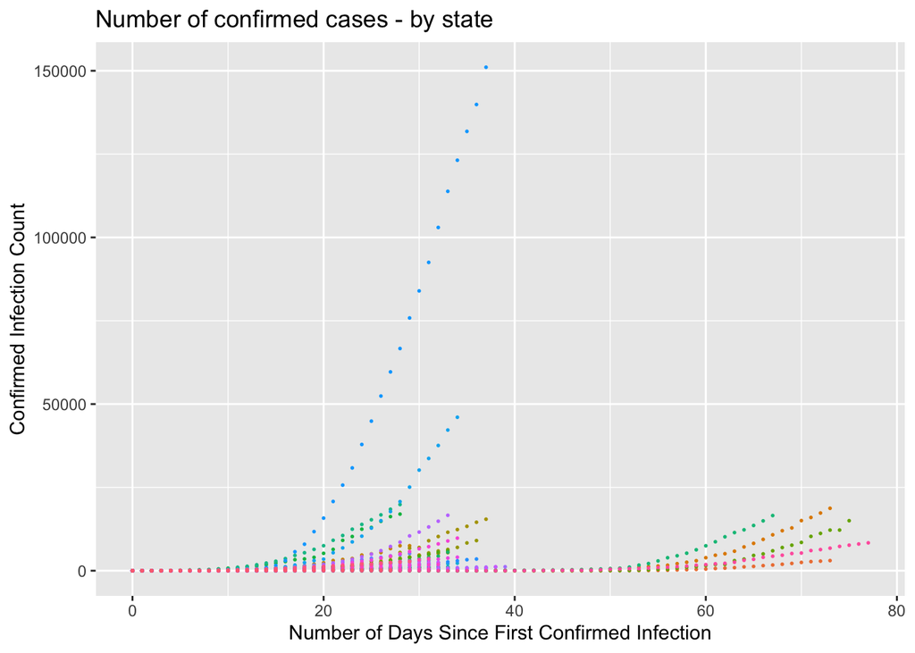

```r
state_plot <- ggplot(state_ts, mapping = aes(x = day_num, y = ct, color = Areaname)) +
  #geom_hex()+
  geom_point(size = .3) +
  xlab("Number of Days Since First Confirmed Infection") +
  ylab("Confirmed Infection Count") +
  theme(legend.position="none") +
  theme(legend.text=element_text(size=6))

state_plot + ggtitle("Number of confirmed cases - by state")
```

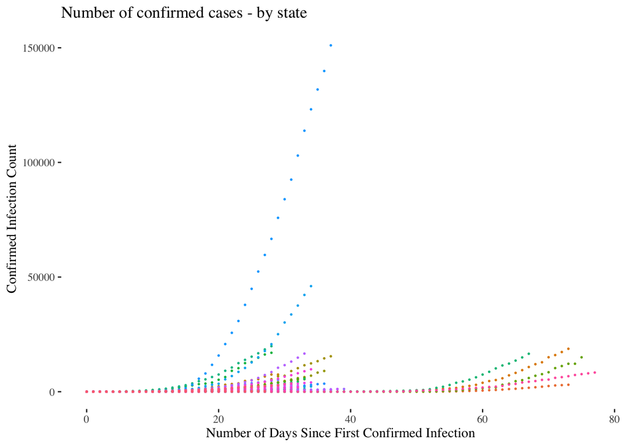

```r
state_plot + ggtitle("Number of confirmed cases - by state") + theme_tufte() + theme(legend.position="none")
```

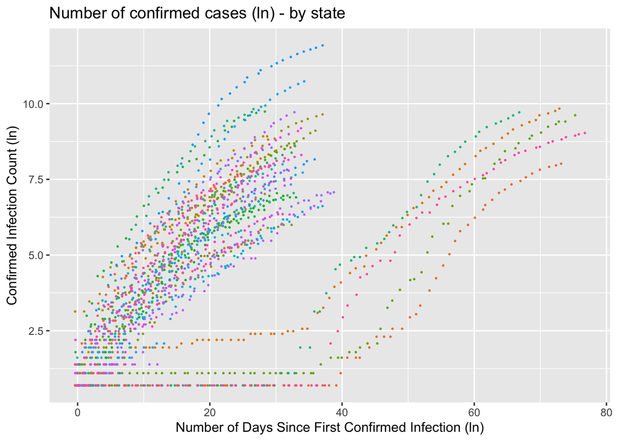

```r
# note use of geom_jitter() instead of geom_point
ln_plot <- ggplot(state_ts, mapping = aes(x = day_num, y = ln_ct, color = Areaname)) +
  #geom_hex()+
  geom_jitter(size = .3) +
  xlab("Number of Days Since First Confirmed Infection (ln)") +
  ylab("Confirmed Infection Count (ln)") +
  ggtitle("Number of confirmed cases by date") +
  theme(legend.position="none") +
  theme(legend.text=element_text(size=6))

ln_plot + ggtitle("Number of confirmed cases (ln) - by state")
```

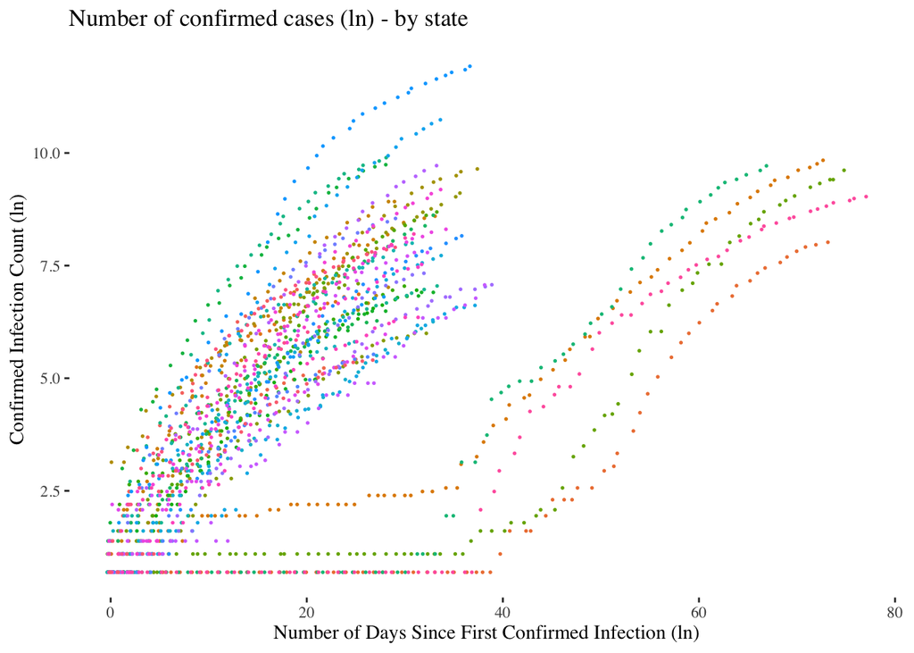

```r
ln_plot + ggtitle("Number of confirmed cases (ln) - by state") + theme_tufte() + theme(legend.position="none")
```

## What are the states that are showing long growth curves (is there a problem?)

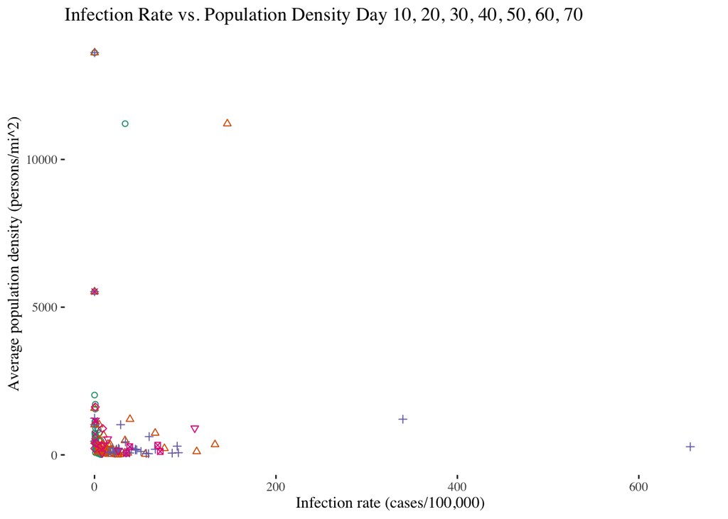

```r
# what are the states that have the long (and early slow) growth curves?
my_colors <- brewer.pal(8, "Dark2")
state_density_data_10d <- state_ts %>%
  filter(day_num == 10) %>%
  group_by(Areaname, start_date) %>%
  summarize(
    max_days = max(day_num),
    max_infection = max(ct),
    max_rate_infection = max(rate_infection),
    avg_density = mean(den_total)
  ) %>%
  arrange(desc(max_rate_infection))

state_density_data_20d <- state_ts %>%
  filter(day_num == 20) %>%
  group_by(Areaname, start_date) %>%
  summarize(
    max_days = max(day_num),
    max_infection = max(ct),
    max_rate_infection = max(rate_infection),
    avg_density = mean(den_total)
  ) %>%
  arrange(desc(max_rate_infection))

state_density_data_30d <- state_ts %>%
  filter(day_num == 30) %>%
  group_by(Areaname, start_date) %>%
  summarize(
    max_days = max(day_num),
    max_infection = max(ct),
    max_rate_infection = max(rate_infection),
    avg_density = mean(den_total)
  ) %>%
  arrange(desc(max_rate_infection))

state_density_data_40d <- state_ts %>%
  filter(day_num == 40) %>%
  group_by(Areaname, start_date) %>%
  summarize(
    max_days = max(day_num),
    max_infection = max(ct),
    max_rate_infection = max(rate_infection),
    avg_density = mean(den_total)
  ) %>%
  arrange(desc(max_rate_infection))

state_density_data_50d <- state_ts %>%
  filter(day_num == 50) %>%
  group_by(Areaname, start_date) %>%
  summarize(
    max_days = max(day_num),
    max_infection = max(ct),
    max_rate_infection = max(rate_infection),
    avg_density = mean(den_total)
  ) %>%
  arrange(desc(max_rate_infection))

state_density_data_60d <- state_ts %>%
  filter(day_num == 60) %>%
  group_by(Areaname, start_date) %>%
  summarize(
    max_days = max(day_num),
    max_infection = max(ct),
    max_rate_infection = max(rate_infection),
    avg_density = mean(den_total)
  ) %>%
  arrange(desc(max_rate_infection))

state_density_data_70d <- state_ts %>%
  filter(day_num == 70) %>%
  group_by(Areaname, start_date) %>%
  summarize(
    max_days = max(day_num),
    max_infection = max(ct),
    max_rate_infection = max(rate_infection),
    avg_density = mean(den_total)
  ) %>%
  arrange(desc(max_rate_infection))

state_density_data_80d <- state_ts %>%
  filter(day_num == 80) %>%
  group_by(Areaname, start_date) %>%
  summarize(
    max_days = max(day_num),
    max_infection = max(ct),
    max_rate_infection = max(rate_infection),
    avg_density = mean(den_total)
  ) %>%
  arrange(desc(max_rate_infection))

base_plot <- ggplot() +
  geom_jitter(data = state_density_data_10d, mapping = aes(x = max_rate_infection, y = avg_density), color = my_colors[1], shape = 1) +
  geom_jitter(data = state_density_data_20d, mapping = aes(x = max_rate_infection, y = avg_density), color = my_colors[2], shape = 2) +
  geom_jitter(data = state_density_data_30d, mapping = aes(x = max_rate_infection, y = avg_density), color = my_colors[3], shape = 3) +
  geom_jitter(data = state_density_data_40d, mapping = aes(x = max_rate_infection, y = avg_density), color = my_colors[4], shape = 4) +
  geom_jitter(data = state_density_data_50d, mapping = aes(x = max_rate_infection, y = avg_density), color = my_colors[4], shape = 5) +
  geom_jitter(data = state_density_data_60d, mapping = aes(x = max_rate_infection, y = avg_density), color = my_colors[4], shape = 6) +
  geom_jitter(data = state_density_data_70d, mapping = aes(x = max_rate_infection, y = avg_density), color = my_colors[4], shape = 7) +
  geom_jitter(data = state_density_data_80d, mapping = aes(x = max_rate_infection, y = avg_density), color = my_colors[4], shape = 8) +
  theme_tufte() +
  xlab("Infection rate (cases/100,000) ") +
  ylab("Average population density (persons/mi^2)") +
  ggtitle("Infection Rate vs. Population Density Day 10, 20, 30, 40, 50, 60, 70")
base_plot
```

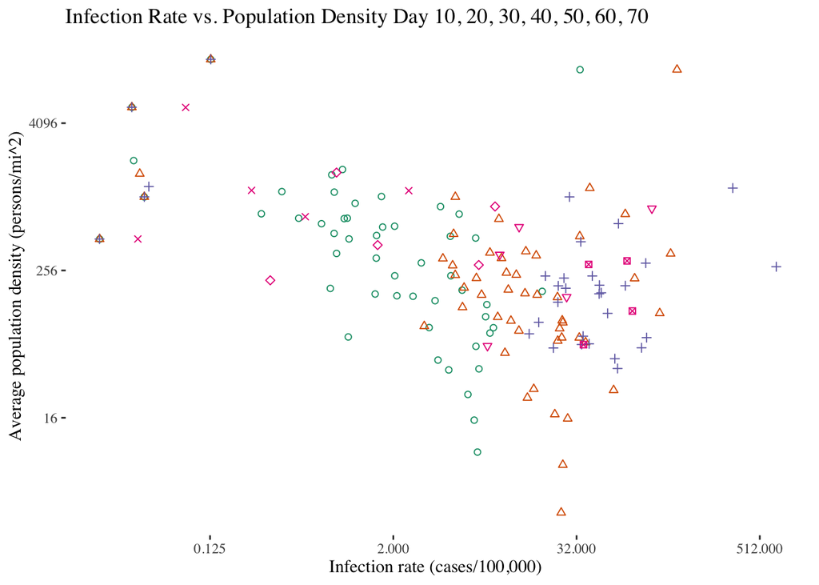

```r
base_plot +
  scale_y_continuous(trans='log2')+
  scale_x_continuous(trans="log2")
```

```r
print(state_density_data_10d)
```

```
## # A tibble: 51 x 6
## # Groups:   Areaname [51]
##    Areaname       start_date max_days max_infection max_rate_infect… avg_density
##    <chr>          <date>        <dbl>         <dbl>            <dbl>       <dbl>
##  1 DISTRICT OF C… 2020-03-16       10           231            33.7     11212.
##  2 LOUISIANA      2020-03-11       10           754            19.0       173.
##  3 ARKANSAS       2020-03-14       10           206             9.10       87.2
##  4 MISSISSIPPI    2020-03-12       10           207             8.63       78.8
##  5 WEST VIRGINIA  2020-03-18       10            96             8.23      135.
##  6 MAINE          2020-03-12       10            81             8.09      107.
##  7 NORTH DAKOTA   2020-03-12       10            28             7.31       40.2
##  8 WYOMING        2020-03-12       10            26             7.15        8.39
##  9 IDAHO          2020-03-14       10            81             6.98       61.4
## 10 MICHIGAN       2020-03-11       10           540             6.96      471.
## # … with 41 more rows
```

```r
state_density_data_10d %>%
  kable() %>%
  kable_styling()
```

| Areaname | start_date | max_days | max_infection | max_rate_infection | avg_density |
| --- | --- | --- | --- | --- | --- |
| DISTRICT OF COLUMBIA | 2020-03-16 | 10 | 231 | 33.7474 | 11212.088 |
| LOUISIANA | 2020-03-11 | 10 | 754 | 19.0192 | 172.866 |
| ARKANSAS | 2020-03-14 | 10 | 206 | 9.1030 | 87.182 |
| MISSISSIPPI | 2020-03-12 | 10 | 207 | 8.6310 | 78.777 |
| WEST VIRGINIA | 2020-03-18 | 10 | 96 | 8.2317 | 134.540 |
| MAINE | 2020-03-12 | 10 | 81 | 8.0883 | 107.163 |
| NORTH DAKOTA | 2020-03-12 | 10 | 28 | 7.3053 | 40.166 |
| WYOMING | 2020-03-12 | 10 | 26 | 7.1477 | 8.387 |
| IDAHO | 2020-03-14 | 10 | 81 | 6.9832 | 61.383 |
| MICHIGAN | 2020-03-11 | 10 | 540 | 6.9575 | 471.199 |
| ALASKA | 2020-03-14 | 10 | 34 | 6.7984 | 15.304 |
| MONTANA | 2020-03-14 | 10 | 45 | 6.1862 | 24.812 |
| ALABAMA | 2020-03-13 | 10 | 196 | 5.6590 | 176.628 |
| CONNECTICUT | 2020-03-10 | 10 | 194 | 5.4167 | 739.620 |
| WISCONSIN | 2020-03-10 | 10 | 219 | 4.7780 | 231.706 |
| DELAWARE | 2020-03-11 | 10 | 45 | 4.7394 | 487.283 |
| NEW MEXICO | 2020-03-11 | 10 | 55 | 4.6286 | 39.364 |
| NEW YORK | 2020-03-02 | 10 | 327 | 4.0835 | 851.988 |
| SOUTH DAKOTA | 2020-03-11 | 10 | 14 | 3.9310 | 47.401 |
| IOWA | 2020-03-09 | 10 | 44 | 3.7620 | 144.903 |
| VERMONT | 2020-03-08 | 10 | 13 | 3.4414 | 87.412 |
| NEBRASKA | 2020-03-06 | 10 | 18 | 3.0552 | 295.425 |
| COLORADO | 2020-03-06 | 10 | 132 | 2.6964 | 157.500 |
| UTAH | 2020-03-07 | 10 | 39 | 2.1134 | 159.006 |
| KANSAS | 2020-03-08 | 10 | 22 | 2.0451 | 231.659 |
| OHIO | 2020-03-10 | 10 | 173 | 2.0375 | 588.599 |
| KENTUCKY | 2020-03-06 | 10 | 21 | 1.7022 | 579.894 |
| VIRGINIA | 2020-03-08 | 10 | 79 | 1.6710 | 1029.982 |
| MINNESOTA | 2020-03-06 | 10 | 53 | 1.5532 | 494.382 |
| SOUTH CAROLINA | 2020-03-07 | 10 | 47 | 1.5463 | 322.846 |
| NEW HAMPSHIRE | 2020-03-02 | 10 | 6 | 1.5192 | 164.321 |
| PENNSYLVANIA | 2020-03-06 | 10 | 79 | 1.1220 | 905.944 |
| INDIANA | 2020-03-06 | 10 | 25 | 1.0234 | 463.620 |
| OREGON | 2020-02-29 | 10 | 14 | 1.0122 | 73.251 |
| TENNESSEE | 2020-03-05 | 10 | 32 | 0.9968 | 684.851 |
| GEORGIA | 2020-03-03 | 10 | 42 | 0.9514 | 679.700 |
| NEW JERSEY | 2020-03-05 | 10 | 72 | 0.9274 | 1712.438 |
| OKLAHOMA | 2020-03-07 | 10 | 17 | 0.8473 | 352.663 |
| MARYLAND | 2020-03-06 | 10 | 42 | 0.8181 | 1118.423 |
| HAWAII | 2020-03-07 | 10 | 10 | 0.8168 | 513.931 |
| RHODE ISLAND | 2020-03-01 | 10 | 5 | 0.7880 | 1549.531 |
| NEVADA | 2020-03-05 | 10 | 20 | 0.7716 | 182.619 |
| MISSOURI | 2020-03-08 | 10 | 18 | 0.6746 | 617.267 |
| NORTH CAROLINA | 2020-03-03 | 10 | 17 | 0.4776 | 683.907 |
| TEXAS | 2020-03-05 | 10 | 63 | 0.3704 | 1129.840 |
| FLORIDA | 2020-03-02 | 10 | 30 | 0.2718 | 744.295 |
| MASSACHUSETTS | 2020-02-01 | 10 | 1 | 0.1263 | 13615.924 |
| WASHINGTON | 2020-01-22 | 10 | 1 | 0.0462 | 1022.541 |
| CALIFORNIA | 2020-01-26 | 10 | 6 | 0.0394 | 2025.153 |
| ILLINOIS | 2020-01-24 | 10 | 2 | 0.0383 | 5525.815 |
| ARIZONA | 2020-01-26 | 10 | 1 | 0.0235 | 462.375 |

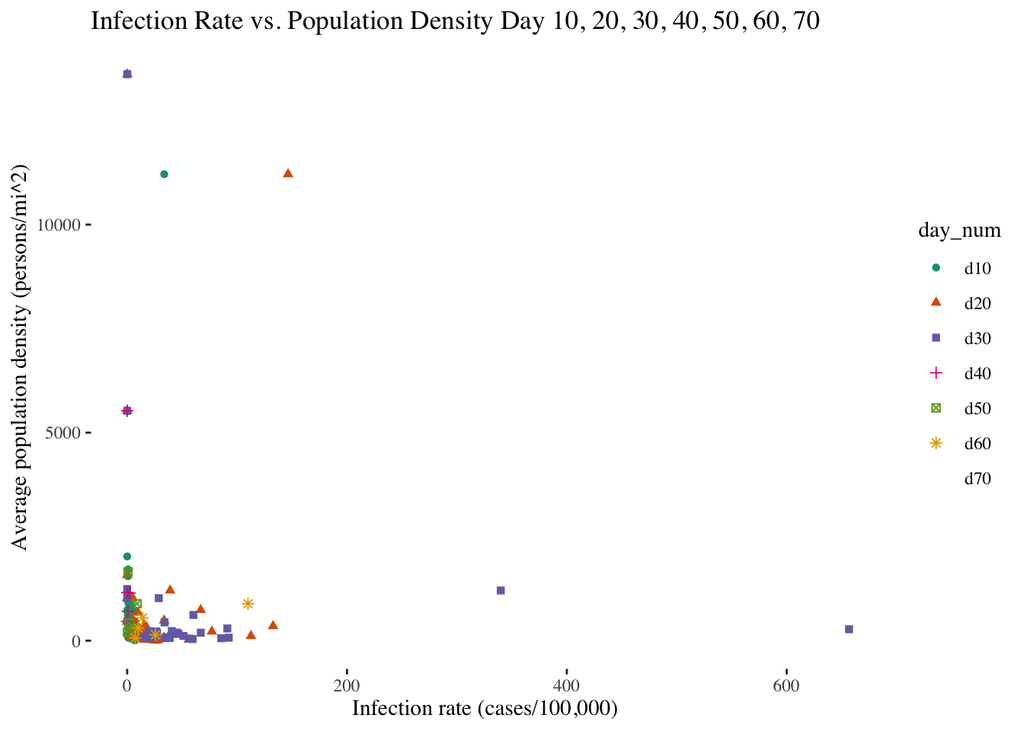

```r
# Another way to do this - by combining out three dataframes into 1 with a new column that identifies the day number for the values

plot_data <-  bind_rows(
  mutate(state_density_data_10d, day_num = "d10"),
  mutate(state_density_data_20d, day_num = "d20"),
  mutate(state_density_data_30d, day_num = "d30"),
  mutate(state_density_data_40d, day_num = "d40"),
  mutate(state_density_data_50d, day_num = "d50"),
  mutate(state_density_data_60d, day_num = "d60"),
  mutate(state_density_data_70d, day_num = "d70"),
  mutate(state_density_data_80d, day_num = "d80")
  )
base_plot <- ggplot(plot_data, mapping = aes(x = max_rate_infection, y = avg_density, color = day_num, shape = day_num)) +
  geom_jitter() +
  scale_color_brewer(palette = "Dark2") +
  theme_tufte() +
  xlab("Infection rate (cases/100,000) ") +
  ylab("Average population density (persons/mi^2)") +
  ggtitle("Infection Rate vs. Population Density Day 10, 20, 30, 40, 50, 60, 70")

base_plot
```

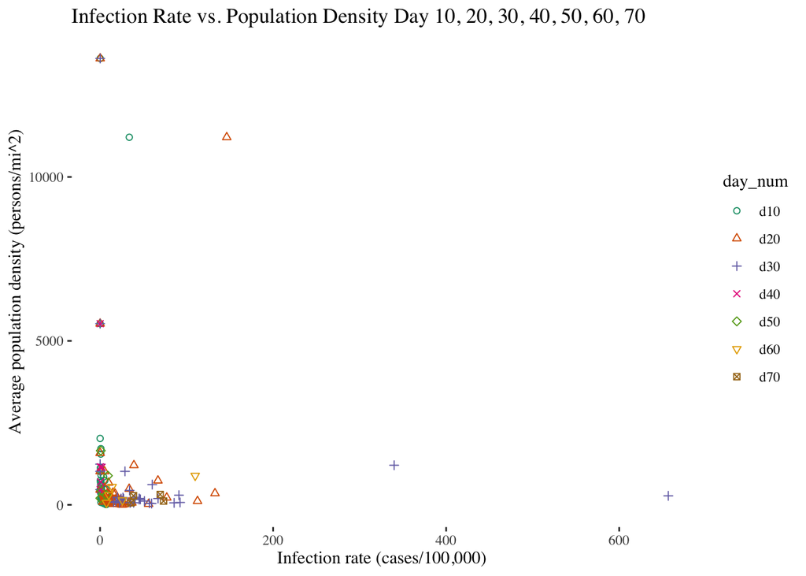

```r
base_plot + scale_shape_manual(values = c(1, 2, 3, 4, 5, 6, 7, 8))
```

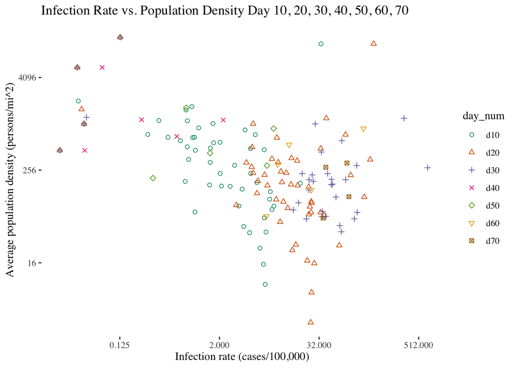

```r
base_plot +
  scale_shape_manual(values = c(1, 2, 3, 4, 5, 6, 7, 8)) +
  scale_y_continuous(trans='log2') +
  scale_x_continuous(trans="log2")
```

```r
print(plot_data)
```

```
## # A tibble: 153 x 7
## # Groups:   Areaname [51]
##    Areaname start_date max_days max_infection max_rate_infect… avg_density
##    <chr>    <date>        <dbl>         <dbl>            <dbl>       <dbl>
##  1 DISTRIC… 2020-03-16       10           231            33.7     11212.
##  2 LOUISIA… 2020-03-11       10           754            19.0       173.
##  3 ARKANSAS 2020-03-14       10           206             9.10       87.2
##  4 MISSISS… 2020-03-12       10           207             8.63       78.8
##  5 WEST VI… 2020-03-18       10            96             8.23      135.
##  6 MAINE    2020-03-12       10            81             8.09      107.
##  7 NORTH D… 2020-03-12       10            28             7.31       40.2
##  8 WYOMING  2020-03-12       10            26             7.15        8.39
##  9 IDAHO    2020-03-14       10            81             6.98       61.4
## 10 MICHIGAN 2020-03-11       10           540             6.96      471.
## # … with 143 more rows, and 1 more variable: day_num <chr>
```

```r
plot_data %>%
  kable() %>%
  kable_styling()
```

| Areaname | start_date | max_days | max_infection | max_rate_infection | avg_density | day_num |
| --- | --- | --- | --- | --- | --- | --- |
| DISTRICT OF COLUMBIA | 2020-03-16 | 10 | 231 | 33.7474 | 11212.088 | d10 |
| LOUISIANA | 2020-03-11 | 10 | 754 | 19.0192 | 172.866 | d10 |
| ARKANSAS | 2020-03-14 | 10 | 206 | 9.1030 | 87.182 | d10 |
| MISSISSIPPI | 2020-03-12 | 10 | 207 | 8.6310 | 78.777 | d10 |
| WEST VIRGINIA | 2020-03-18 | 10 | 96 | 8.2317 | 134.540 | d10 |
| MAINE | 2020-03-12 | 10 | 81 | 8.0883 | 107.163 | d10 |
| NORTH DAKOTA | 2020-03-12 | 10 | 28 | 7.3053 | 40.166 | d10 |
| WYOMING | 2020-03-12 | 10 | 26 | 7.1477 | 8.387 | d10 |
| IDAHO | 2020-03-14 | 10 | 81 | 6.9832 | 61.383 | d10 |
| MICHIGAN | 2020-03-11 | 10 | 540 | 6.9575 | 471.199 | d10 |
| ALASKA | 2020-03-14 | 10 | 34 | 6.7984 | 15.304 | d10 |
| MONTANA | 2020-03-14 | 10 | 45 | 6.1862 | 24.812 | d10 |
| ALABAMA | 2020-03-13 | 10 | 196 | 5.6590 | 176.628 | d10 |
| CONNECTICUT | 2020-03-10 | 10 | 194 | 5.4167 | 739.620 | d10 |
| WISCONSIN | 2020-03-10 | 10 | 219 | 4.7780 | 231.706 | d10 |
| DELAWARE | 2020-03-11 | 10 | 45 | 4.7394 | 487.283 | d10 |
| NEW MEXICO | 2020-03-11 | 10 | 55 | 4.6286 | 39.364 | d10 |
| NEW YORK | 2020-03-02 | 10 | 327 | 4.0835 | 851.988 | d10 |
| SOUTH DAKOTA | 2020-03-11 | 10 | 14 | 3.9310 | 47.401 | d10 |
| IOWA | 2020-03-09 | 10 | 44 | 3.7620 | 144.903 | d10 |
| VERMONT | 2020-03-08 | 10 | 13 | 3.4414 | 87.412 | d10 |
| NEBRASKA | 2020-03-06 | 10 | 18 | 3.0552 | 295.425 | d10 |
| COLORADO | 2020-03-06 | 10 | 132 | 2.6964 | 157.500 | d10 |
| UTAH | 2020-03-07 | 10 | 39 | 2.1134 | 159.006 | d10 |
| KANSAS | 2020-03-08 | 10 | 22 | 2.0451 | 231.659 | d10 |
| OHIO | 2020-03-10 | 10 | 173 | 2.0375 | 588.599 | d10 |
| KENTUCKY | 2020-03-06 | 10 | 21 | 1.7022 | 579.894 | d10 |
| VIRGINIA | 2020-03-08 | 10 | 79 | 1.6710 | 1029.982 | d10 |
| MINNESOTA | 2020-03-06 | 10 | 53 | 1.5532 | 494.382 | d10 |
| SOUTH CAROLINA | 2020-03-07 | 10 | 47 | 1.5463 | 322.846 | d10 |

[output cut: 123 more lines]

```r
purl('workflow.rmd', output = "workflow.R")
```

[output not shown]

```
## [1] "workflow.R"
```